# Assignment 5: The Gender Wage Gap

Author

Jose Fuentes

Published

February 1, 2023

*Instructions:*

- You may work either by yourself, or in a group of up to two. Note that you will receive the same grade. If you choose to work together, make sure BOTH of your names are in the metadata above. Only one person needs to submit via Canvas. IMPORTANT: Please do not have more than one person submit it!!! You will both see the grade and comments.
- Submit both the .qmd file and the rendered HTML file.
- I have provided space below for all of your written answers and any code. If I expect any code, there is gray space below the question available for your use.
- You should periodically render, perhaps even after each question. It is easier to read the text using the knitted file, and you can see the outputs more clearly too!
- Just for your information: You may see some HTML code in the .qmd source file. Feel free to ignore these and there is no reason to change them.
- Prior to starting, set your working directory and clear your global environmrnt in the first chunk of code below. Make sure to remove the hashtag before setting your working directory.

# Introduction

> *“The most commonly cited statistic for the gender wage gap asserts that women earn only 77 cents for every dollar earned by men. However, a great deal of contention surrounds statistics measuring and quantifying the gender wage gap, and this confusion is not entirely without merit. Some of the controversy around wage-gap estimates and figures is at least partly due to the fact that, like many statistics, the exact figure changes slightly depending on the data source used. With competing statistics and a highly politicized issue, the very existence of the wage gap is often called into question—along with its significance and driving causes. The ‘77 cents’ formulation is a colloquialism—shorthand for expressing a complex economic truth. Simply put, what it conveys is the fact that, if you average out what all women, working full time, year round, earn and compare that number to what all men working full time, year round, earn, you find that women take home 77 percent of what men do.”*
> - *Sarah Jane Glynn, Center for American Progress*

With the children shipped off to the grandparents, Joe is quickly looking forward to date night with his wife, Isabella. They were planning to head off to a movie, followed by a dinner at the new swanky French restaurant in town. However, his wife, the Chief Financial Officer of a 12-year old up-and-coming technology company, had only work on her mind.

“We’re going public soon, so I have a ton of work due yesterday. Can we take a raincheck on date night so I can work a few more hours tonight?” Isabella asked.

Joe was perplexed. Isabella had planned the date and was looking forward to it all week. “Of course, honey. But when will you get a chance to relax?” Joe was worried about her health, especially since she recently delivered their third child a little over a month ago. Isabella returned to work after only two weeks off. Given the amount of stress she faced from the delivery, Joe wanted to make sure she gets a combination of rest and relaxation. “I wish you would’ve been able to take a longer leave than two weeks.”

But Isabella could do nothing but worry about his comment. “Do you know how difficult it is for my career if I take off for a few months? My friend, Deena, lost most of her responsibilities after taking off six months after having a baby. Then her manager passed on her for a raise and a promotion. Not to mention that taking more time off means that my peers will talk about how I don’t take the company seriously! Please go and learn more about how much less women make than men and all the reasons for it. Then come back and talk to me.”

Isabella knew Joe could not resist learning more; he’s a superb data analyst who naturally believes in numbers. But despite knowing a little about the gender earnings gap from the media, he does not understand all the reasons why the gap existed. So he apologizes to his wife, and immediately sat at his computer to work on learning more about the problem.

# Some Earnings Data

Joe does some digging through web searches. While he locates some useful research done on the topic, he wanted to see it in the numbers. He finds some earnings data available on a job search site. The site, SuperProfessionalJobs.com, has de-identified individual-level data available that includes variables on gender, birth country, job title, salary, industry, years of experience, and location. The data is from a survey completed online for users of the site. In total, 13,476 users were asked to complete the survey. However, the total sample size of completed surveys is 1,557. He does a quick crunch of numbers and noticed that 38% of sampled users did not enter in a salary amount.

Joe thinks there might be some issues that may bias the analysis if he uses this data. Help Joe out here:

## Question 1

**Name two issues specifically pertaining to the SAMPLE of the SuperProfessionalJobs.com data that might give Joe an inaccurate estimate about the population. Be specific about what the issues are and how it can lead to an inaccurate estimate when analyzing the data.**

Issue 1: [If 38% of people didn’t entered their salary amount in the sample, it might not be representative of the population and the results of income might be skewed. It will only show an average of the people who answered which might be far off from the actual population average.]

Issue 2: [Out of that 38% that didn’t enter the salary amount, how many of them are females vs males. Is this portion of the data representative of the sample size of 1557? If not, once again there might be some inaccurate estimates]

## Question 2

**Name two issues that may arise pertaining to the variables available in the SuperProfessionalJobs.com data which might give Joe an inaccurate estimate about the population? (i.e., are the variables sufficient? What other variables should one want?)**

Issue 1: [As we discussed in class, an issue would be that there are sometimes values like 999999 that are null variables, and if that’s the case we would want to remove those before continuing with the analysis. ]

Issue 2: [Without a data dictionary for me to look at it’s hard to consult Joe on what to do. But an vague guide is to always ask questions pertaining to the variables. Are there any categorical variables that wee need to consider? Does birth country mean that they still live there? is there an equal amount of people in the location to say that the data is significantly accurate.]

## Question 3

**Think about your answers for Questions 1 and 2. Describe one specific situation how these issues might exacerbate the gender earnings gap and a second situation that might attenuate it (i.e., make it seem smaller than reality). Be specific about it.**

Exacerbate?: [It could be that in we’re looking at a country like China where it’s more likely for there to be men, due to the overpopulation and families wanting to pass down their last names. “China has recorded a significant imbalance sex ratio toward the male population, meaning there are fewer women than men”(Statista).This could also lead to the question about when the data was recorded, is it representative of todays date? this is one exaple of how the issue may be exacerbated. ]

https://www.statista.com/statistics/282119/china-sex-ratio-by-age-group/#:~:text=While%20the%20difference%20of%20gender,100%20females%20as%20of%202021.

Attenuate?: [If we only compare the income by age and gender it might seem as though it’s more equal depending on the age, because the younger both genders are the less money both make. This is also something to consider for when analyzing the data.]

Joe calls his co-worker, Melinda. She talks through some of the issues possible in the analysis with him. And before hanging up, Melinda tells Joe that she heard about a data set used primarily by demographic researchers called IPUMS. His interest immediately turns.

# IPUMS and ACS

Joe turns to the Integrated Public Use Microdata Series [IPUMS], the world’s largest collection of publicly available individual-level population. Housed at the Institute for Social Research and Data Innovation at the University of Minnesota under the direction of Professor Steve Ruggles (Ruggles et al. 2020), IPUMS contains downloadable data from the US Census from 1790-2010, the Current Population Survey [CPS] from 1962-Present, and the American Community Survey [ACS] from 2000-present. The database facilitates easy access for researchers and students (through qualified instructors) by providing consistent variable names, sampling strategies, and documentation.

Joe went to download some relevant data from the website. He downloaded data from the American Community Survey (ACS) from 2015 to 2018. The ACS is a monthly sent to nearly 300,000 residents of the US each month to collect data on demographics, earnings, employment, education, and housing, and language proficiency. This is the most accurate picture of the US population that we have today, and is often regarded as the most representative sample of the population.

The data downloaded by Joe includes variables for earnings, employment, and children for persons age 18-65. The ACS data is good for such an analysis since the sample data is supposed to be highly representative of the US population. The first thing Joe wants to do is to do some pre-processing of the data and to check out the descriptive statistics. He calls you, his part-time Research Assistant, to do some pre-processing of the data in R:

# Pre-Processing the Data

## Question 4

**Import the CSV file into RStudio. (Note that you should’ve set your working directory in the first chunk of code already) Name this data frame “ACS”. Familiarize yourself with the structure of the data and check out the data dictionary for a brief overview of the variables.**

```r
ACS <- read.csv("ACS.CSV")
```

## Question 5

**We want to generate some new variables and change some data structures. Do the following in the code:**

1. The raw data contains a “sex” variable for gender where the possibly data is either male or a female. Construct a new dummy variable called “female”, where anyone who is a female is denoted by a 1; 0 otherwise.
2. Generate a new dummy variable called “baby_last_yr” using “fertyr”, where 1 represents a yes and 0 represent otherwise.
3. There is a variable for ethnicity for “hispan”. Generate a new dummy variable called “hispanic_dummy” where 0 represents “Not Hispanic” and 1 represents anyone who is any type of Hispanic. Hint: make sure you table() the possibilities first. There are multiple ways to do this. (If you want to use it, you can use “|” to mean “OR”, but this is also not necessary).
4. Generate a single dummy variable called “notemployed” for anyone whose “empstat” contains the value of either “Unemployed” or “Not in labor force.”
5. Generate one dummy variable called “married” for anyone whose “marst” contains a value of either “Married, spouse present” or “Married, spouse absent”.
6. Change the data type of “uhrswork” to numeric.
7. Change the data structure of “age” to numeric. Note that this forces NA’s to non-numeric values. The original “age” variable contains values such as “Less than 1 year old” and “90 (90+ in 1980 and 1990)”, but we find this irrelevant since almost no one in these populations are working anyways! So that is okay for the analysis we are doing at least. Prior to making the change, you can actually see this by using the table() function if you wish.

```r
#A. dummy variable called "female", where anyone who is a female is denoted by a 1; 0 otherwise
ACS$Female = ifelse(ACS$sex == 'Female', 1, 0)

  #Checking my work
  #head(ACS[,c('sex', 'Female')])

#B. dummy variable where of baby last year where 1 represents a yes and 0 represent otherwise
ACS$baby_last_yr = ifelse(ACS$fertyr == 'Yes', 1,0)

  #Checking my work
 # View(ACS[,c('baby_last_yr', 'fertyr')])

#C. dummy variable where 1 anyone who is a type of hispanic, and 0 not hispanic.
ACS$hispan = as.factor(ACS$hispan)
levels(ACS$hispan)
```

```
[1] "Cuban"        "Mexican"      "Not Hispanic" "Other"        "Puerto Rican"
```

```r
ACS$hispanic_dummy = ifelse(ACS$hispan == "Cuban"
                            |ACS$hispan == "Mexican"
                            |ACS$hispan == "Other"
                            |ACS$hispan == "Puerto Rican", 1, 0)
  #Checking my work
  #View(ACS[,c('hispan', 'hispanic_dummy')])


#D.  dummy variable called "notemployed" for anyone whose "empstat" contains the value of either “Unemployed” or “Not in labor force.
ACS$empstat = as.factor(ACS$empstat)
levels(ACS$empstat)
```

```
[1] "Employed"           "N/A"                "Not in labor force"
[4] "Unemployed"
```

```r
ACS$notemployed = ifelse(ACS$empstat == "Unemployed"
                         |ACS$empstat =="Not in labor force"
                         ,1,0)

  #Checking my work
  #View(ACS[,c("empstat", "notemployed")])


#E.  Generate one dummy variable called "married" for anyone whose "marst" contains a value of either “Married, spouse #    present” or “Married, spouse absent”.
ACS$marst = as.factor(ACS$marst)
levels(ACS$marst)
```

```
[1] "Divorced"                "Married, spouse absent"
[3] "Married, spouse present" "Never married/single"
[5] "Separated"               "Widowed"
```

```r
ACS$married = ifelse(ACS$marst == "Married, spouse absent"
                     |ACS$marst == "Married, spouse present"
                     ,1,0)
 #Check my work
 #View(ACS[,c("married","marst")])


#F.  Change the data type of "uhrswork" to numeric.
ACS$uhrswork = as.numeric(ACS$uhrswork)
anyNA(ACS$uhrswork)
```

```
[1] TRUE
```

```r
#G.  Change the data structure of "age" to numeric.
ACS$age = as.numeric(ACS$age)
anyNA(ACS$age)
```

```
[1] TRUE
```

```r
sum(is.na(ACS$age))
```

```
[1] 11457
```

## Question 6

**Run some descriptive statistics using the datasummary_skim() function using the modelsummary package. Make sure to format it with three decimal points (you can insert “, fmt=3” before closing the parentheses. Answer the following:**

1. What percent of the sample is Hispanic?
2. What is the median age of the sample?
3. Do you see any normally distributed variables?
4. What percent of the sample has uhrswork is missing? What percent of incwage is missing? How would you rationalize this? [Feel free to check out the data to speculate why it might be]

A. 0.160

B. 37.000

C. I would say that uhrswork is distributed normally based of the little graph on the right

D. uhrswork = 43% of the data is missing incwage = 0% of the data is missing

The reason why uhrswork might have missing values is because 00 represents no hours worked, and 99 represents 99 hours or more worked. This is unreseanable because there are only 168 hours in a week

```r
library(modelsummary)
datasummary_skim(ACS, fmt = "%.3f")
```

|  | Unique (#) | Missing (%) | Mean | SD | Min | Median | Max |  |
| --- | --- | --- | --- | --- | --- | --- | --- | --- |
| year | 3 | 0 | 2017.004 | 0.815 | 2016.000 | 2017.000 | 2018.000 |  |
| perwt | 1079 | 0 | 106.192 | 85.867 | 1.000 | 83.000 | 1889.000 |  |
| age | 96 | 1 | 36.923 | 20.492 | 1.000 | 37.000 | 96.000 |  |
| uhrswork | 99 | 43 | 38.659 | 12.628 | 1.000 | 40.000 | 98.000 |  |
| incwage | 989 | 0 | 235251.561 | 394802.282 | 0.000 | 32000.000 | 999999.000 |  |
| Female | 2 | 0 | 0.500 | 0.500 | 0.000 | 0.000 | 1.000 |  |
| baby_last_yr | 2 | 0 | 0.013 | 0.114 | 0.000 | 0.000 | 1.000 |  |
| hispanic_dummy | 2 | 0 | 0.160 | 0.367 | 0.000 | 0.000 | 1.000 |  |
| notemployed | 2 | 0 | 0.272 | 0.445 | 0.000 | 0.000 | 1.000 |  |
| married | 2 | 0 | 0.413 | 0.492 | 0.000 | 0.000 | 1.000 |  |

```r
table(ACS$uhrswork)
```

```
     1      2      3      4      5      6      7      8      9     10     11
   926   1339   1222   2136   2098   1924    770   3977    613   6842    262
    12     13     14     15     16     17     18     19     20     21     22
  4534    431    854   8284   3831    524   2005    396  24694    616   1076
    23     24     25     26     27     28     29     30     31     32     33
   563   5707  13723    827    988   2488    644  26256    233   8308    843
    34     35     36     37     38     39     40     41     42     43     44
  1000  18043   7611   3777   6244   1184 248321    835   5353   2055   2254
    45     46     47     48     49     50     51     52     53     54     55
 34164   1432    911   6938    382  49856    168   1669    351    545  10002
    56     57     58     59     60     61     62     63     64     65     66
  1104    168    480     70  21133     34    182    110    162   2818    154
    67     68     69     70     71     72     73     74     75     76     77
    50    148     29   4238      7    830     24     38    739     50     45
    78     79     80     81     82     83     84     85     86     87     88
    61      9   2735      8     42     10    604    162     24     22     43
    89     90     91     92     93     94     95     96     97     98
     6    455     30     14      4      9     36     98      4     58
```

```r
anyNA(ACS$uhrswork)
```

```
[1] TRUE
```

```r
#View(table(ACS$uhrswork))
```

## Question 7

**As you might have noticed during Assignment 4, the data for incwage is off. The mean is over $200,000 and a substantial number of people have income that is either 999998 or 999999. That is because 999999 = N/A and 999998 = Missing.**

Generate a new subset data frame, called “ACS_subset”, of individuals where anybody re-coded to make a incwage of 999999 (N/A) or 999998 (missing) are NOT included in the data frame. There are multiple ways to do this, but I prefer that you use our class materials. Alternatively, you can look up the subset() function. Also, note that incwage is an integer variable in the data, which means you can treat it as a number when coding.

```r
ACS_subset = subset(ACS, !(incwage %in% c(999999, 999998)))

#Look at incwage column, if it contains values 999999 or 999998 mark it as true. Then reverse it lol
#        ! (incwage         %in%                 c(999999, 999998))

#Now create a subset dataset from the datatable ACS using the logical function where  999999 and 999998 is False (meaning don't include it)


#before
mean(ACS$incwage)
```

```
[1] 235251.6
```

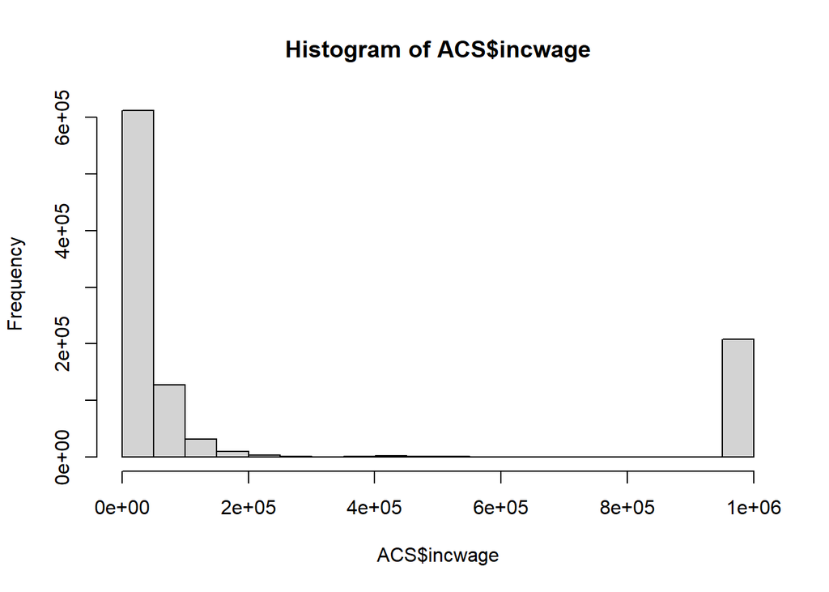

```r
hist(ACS$incwage)
```

```r
#after
mean(ACS_subset$incwage)
```

```
[1] 34851.16
```

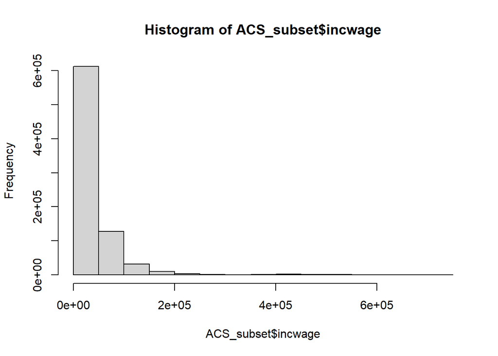

```r
hist(ACS_subset$incwage)
```

## Question 8

You want to assess how different the subsetted sample (ACS_subset) is from the original sample (ACS). Since you subsetted based on missing and N/A values for income wages, we can run some simple regressions to tell us the difference between the two samples. Specifically, I want you to test for statistical differences between the two data frames in the following variables: female, age, hispanic, baby_last_yr, notemployed, and married.

You must do the following:

1. Create a variable called “subset”, first in “ACS_subset” then in “ACS”. It should be a 1 in ACS_subset and 0 in ACS. Note that this will end up as a dummy variable that will tell us whether it is data from either data frame.
2. Combine the two dataset (using rbind) and call this data frame “ACS_compare”.
3. Run the appropriate regressions to test for statistical differences. Use modelsummary() to show all the regressions.

```r
#Add 1 if the variable is from the subset, add 0 if the variable is from the original one
ACS_subset$subset = 1
ACS$subset = 0

#combine the two
ACS_compare = rbind(ACS,ACS_subset)

  #checking my work
  #View(table(ACS_compare$subset))


#Run regresions to check for statistical differences


models_ACSCOMPARE <- list()
models_ACSCOMPARE[['Female']] <- lm(Female~subset, data=ACS_compare)
models_ACSCOMPARE[['age']] <- lm(age~subset, data=ACS_compare)
models_ACSCOMPARE[['hispan']] <- lm(hispanic_dummy~subset, data=ACS_compare)
models_ACSCOMPARE[['baby_last_yr']] <- lm(baby_last_yr~subset, data=ACS_compare)
models_ACSCOMPARE[['notemployed']] <- lm(notemployed~subset, data=ACS_compare)
models_ACSCOMPARE[['married']] <- lm(married~subset, data=ACS_compare)


#Summary
modelsummary(models_ACSCOMPARE, stars=TRUE, title="Table 1. ACS compare statistical differences")
```

Table 1. ACS compare statistical differences

|  | Female | age | hispan | baby_last_yr | notemployed | married |
| --- | --- | --- | --- | --- | --- | --- |
| (Intercept) | 0.500*** | 36.923*** | 0.160*** | 0.013*** | 0.272*** | 0.413*** |
|  | (0.000) | (0.019) | (0.000) | (0.000) | (0.000) | (0.000) |
| subset | 0.003*** | 7.115*** | −0.013*** | 0.003*** | 0.071*** | 0.108*** |
|  | (0.001) | (0.028) | (0.001) | (0.000) | (0.001) | (0.001) |
| Num.Obs. | 1792363 | 1780546 | 1792363 | 1792363 | 1792363 | 1792363 |
| R2 | 0.000 | 0.034 | 0.000 | 0.000 | 0.006 | 0.012 |
| R2 Adj. | 0.000 | 0.034 | 0.000 | 0.000 | 0.006 | 0.012 |
| AIC | 2601744.0 | 15488409.6 | 1434633.8 | −2506528.1 | 2291018.0 | 2569864.1 |
| BIC | 2601781.2 | 15488446.8 | 1434671.0 | −2506490.9 | 2291055.2 | 2569901.3 |
| Log.Lik. | −1300869.019 | −7744201.792 | −717313.888 | 1253267.055 | −1145506.006 | −1284929.060 |
| F | 15.059 | 63414.931 | 613.815 | 359.487 | 10696.717 | 21058.168 |
| RMSE | 0.50 | 18.74 | 0.36 | 0.12 | 0.46 | 0.50 |

+ p < 0.1, * p < 0.05, ** p < 0.01, *** p < 0.001

## Question 9

Using your outputs from the previous question, describe what you find out about people with missing or N/A incwage.

# Estimating the Gender Earning Gap

After pre-processing the data, Joe wants to estimate the difference in earnings between male and female workers in general. This could give him some idea into what the raw differences in earnings would be.

## Question 10

**Run a regression using incwage as the dependent variable and female as the independent variable using ACS_subset. Store this regression as “simple_reg” (and we will refer to it later) Write a sentence to properly interpret the constant (y-intercept). Then interpret the slope for the female coefficient.**

Slope (B1): for every female in the data, income will reduce by $16,431.74 dollars all else held constant.

```r
simple_reg = lm(incwage ~ Female, data = ACS_subset)
summary(simple_reg)
```

```
Call:
lm(formula = incwage ~ Female, data = ACS_subset)

Residuals:
   Min     1Q Median     3Q    Max
-43113 -26681 -16113  13319 709319

Coefficients:
             Estimate Std. Error t value Pr(>|t|)
(Intercept)  43113.22      90.55   476.1   <2e-16 ***
Female      -16431.74     127.70  -128.7   <2e-16 ***
---
Signif. codes:  0 '***' 0.001 '**' 0.01 '*' 0.05 '.' 0.1 ' ' 1

Residual standard error: 56840 on 792361 degrees of freedom
Multiple R-squared:  0.02047,   Adjusted R-squared:  0.02047
F-statistic: 1.656e+04 on 1 and 792361 DF,  p-value: < 2.2e-16
```

```r
#plot(simple_reg)
```

## Question 11

**Using only the answer and output from the previous question, estimate the percent of income and wages that women make relative to men using. Feel free to use R as a calculator in the gray chunk to show your calculations. [Hint: the only numbers you need to calculate this are the coefficients]**

Answer:Women only make 61.89% relative to men

```r
#According to the simple regression
#Men make 43,113.22
#Women make 26,681.48 which is $16,431.74 less than men
women_income = 43113.22-16431.74
women_income
```

```
[1] 26681.48
```

```r
men_income = 43113.22

percentage_women_make_relative_to_Men = (women_income/men_income)*100

percentage_women_make_relative_to_Men
```

```
[1] 61.887
```

Thinking about what to do next, Joe calls his buddy, Foster. Upon hearing what Joe was up to, Foster says, “There should be differences between people with and without children and whether they are employed, the quantity of time they work, etc.” Ideas are flowing now.

Joe continues his analysis on top of the last regression he ran by also controlling for additional variables. Joe asks you to think about what covariates (control variables) might be appropriate.

## Question 12

**Look through the data set. Choose AT LEAST 4 variables you believe could hypothetically affect someone’s income and wages. State the variables and a reason why you can see that variable affecting income and wages. Feel free to use more than 4 variables if you feel like they affect the dependent variable, but make sure the data structure is formatted correctly for use in regression. [Note: In R Markdown, you can use “*” as bullet points in the HTML file. Just make sure there is an additional line between each bullet point for it to work properly. Below, I use bullet points here.]**

- 1st Variable & Why: I will use hours worked to see if maybe it has any affect, for instance if it’s the case that women work less it will show up, and maybe that’s the reason why women earn less.

(#post note: I was splitting the work throughout days and forgot that uhrs worked had so many n/a’s which might skew the data. As in the age column before. I didn’t know what to do so i just proceeded and accepted the L. )

- 2nd Variable & Why: I will also used unemployment to see whether the reason for a female making less is because there is a large percentage of women who are unemployed.
- 3rd Variable & Why: I will use is baby_last_yr to see whether because women have a baby they have to take care of it and have to stop working.
- 4th Variable & Why: Lastly I will use married. it is common in the USA to have the husband work and the women stay at home, although times have changed in recent year, having this in the regression can show me if there is any difference.

## Question 13

**Incorporate all of the variables you selected from the previous question as independent variables in a new regression. Run the regression with the dependent variable as “incwage” and independent variable includes “female” and all of your control variables from the previous question. Make sure to use “ACS_subset”. Store this regression as “multiple_reg” (and we will refer to it later).**

```r
multiple_reg = lm(incwage ~ Female+uhrswork+notemployed+baby_last_yr+married, data = ACS_subset)
summary(multiple_reg)
```

```
Call:
lm(formula = incwage ~ Female + uhrswork + notemployed + baby_last_yr +
    married, data = ACS_subset)

Residuals:
    Min      1Q  Median      3Q     Max
-148775  -25533   -9631   10223  710353

Coefficients:
               Estimate Std. Error t value Pr(>|t|)
(Intercept)  -11254.978    290.057 -38.803  < 2e-16 ***
Female        -9809.009    156.721 -62.589  < 2e-16 ***
uhrswork       1438.501      6.342 226.823  < 2e-16 ***
notemployed  -19115.876    274.873 -69.544  < 2e-16 ***
baby_last_yr  -4384.253    608.360  -7.207 5.74e-13 ***
married       19056.931    155.291 122.717  < 2e-16 ***
---
Signif. codes:  0 '***' 0.001 '**' 0.01 '*' 0.05 '.' 0.1 ' ' 1

Residual standard error: 57390 on 570070 degrees of freedom
  (222287 observations deleted due to missingness)
Multiple R-squared:  0.1585,    Adjusted R-squared:  0.1585
F-statistic: 2.148e+04 on 5 and 570070 DF,  p-value: < 2.2e-16
```

```r
#plot(multiple_reg)
```

# Estimates with Weights

Foster also says, “As I understand it, I believe the ACS data is at the individual-level (meaning each row is a person) but people from different geographic areas do not respond equally to the ACS survey. As a result, you have to weigh certain people more or less to get an accurate representation of the country. There is an ACS variable for that – PERWT.” Joe wants to repeat his estimates using the weight variable.

## Question 14

Re-run your analysis from the previous question and add in the weights. Make sure to use “ACS_subset”. Store this regression as “multiple_wts”

```r
multiple_wts = lm(incwage ~ Female+uhrswork+notemployed+baby_last_yr+married,ACS_subset,weight=perwt)
summary(multiple_wts)
```

```
Call:
lm(formula = incwage ~ Female + uhrswork + notemployed + baby_last_yr +
    married, data = ACS_subset, weights = perwt)

Weighted Residuals:
     Min       1Q   Median       3Q      Max
-2872982  -218091   -70474    99018 14483941

Coefficients:
              Estimate Std. Error t value Pr(>|t|)
(Intercept)  -11601.83     276.41 -41.973  < 2e-16 ***
Female        -8765.75     148.27 -59.120  < 2e-16 ***
uhrswork       1395.48       6.13 227.634  < 2e-16 ***
notemployed  -17800.64     268.37 -66.328  < 2e-16 ***
baby_last_yr  -4483.44     562.17  -7.975 1.52e-15 ***
married       19154.52     146.17 131.045  < 2e-16 ***
---
Signif. codes:  0 '***' 0.001 '**' 0.01 '*' 0.05 '.' 0.1 ' ' 1

Residual standard error: 558200 on 570070 degrees of freedom
  (222287 observations deleted due to missingness)
Multiple R-squared:  0.1594,    Adjusted R-squared:  0.1594
F-statistic: 2.162e+04 on 5 and 570070 DF,  p-value: < 2.2e-16
```

## Question 15

You stored three regressions with different estimates: simple_reg, multiple_reg, multiple_wts. Using modelsummary, show these regressions in one table.

```r
models <- list()

models[['Simple']] = simple_reg
models[['Multiple']] = multiple_reg
models[['Mulitple + Weights']] = multiple_wts

modelsummary(models, title="All Three Regressions")
```

All Three Regressions

|  | Simple | Multiple | Mulitple + Weights |
| --- | --- | --- | --- |
| (Intercept) | 43113.221 | −11254.978 | −11601.826 |
|  | (90.551) | (290.057) | (276.409) |
| Female | −16431.738 | −9809.009 | −8765.753 |
|  | (127.700) | (156.721) | (148.270) |
| uhrswork |  | 1438.501 | 1395.484 |
|  |  | (6.342) | (6.130) |
| notemployed |  | −19115.876 | −17800.638 |
|  |  | (274.873) | (268.372) |
| baby_last_yr |  | −4384.253 | −4483.436 |
|  |  | (608.360) | (562.166) |
| married |  | 19056.931 | 19154.524 |
|  |  | (155.291) | (146.168) |
| Num.Obs. | 792363 | 570076 | 570076 |
| R2 | 0.020 | 0.159 | 0.159 |
| R2 Adj. | 0.020 | 0.159 | 0.159 |
| AIC | 19598069.8 | 14111245.1 | 14194826.4 |
| BIC | 19598104.5 | 14111323.9 | 14194905.2 |
| Log.Lik. | −9799031.895 | −7055615.559 | −7097406.207 |
| F | 16557.090 | 21480.205 | 21615.825 |
| RMSE | 56835.04 | 57393.38 | 57416.83 |

# Summarizing and Interpreting

## Question 16

Joe deems the last regression you ran as the most “accurate” one. Using the “female” beta coefficient, estimate the gender wage gap by doing the following:

- Calculate and store the mean(incwage) for males in “ACS_subset”. Store this as “inc_males”.
- Store the beta coefficient for females from the last regression you ran. Store this number as “diff_females”. If it is a negative number, make sure to store as a negative number!
- Run the equation (inc_males+diff_females)/inc_males. This is the estimate of the how much females make relative to how much males make in the US.

**What is your estimate?**

```r
# Calculate and store the mean(incwage) for males in "ACS_subset". Store this as "inc_males".
inc_males = mean(ACS_subset[ACS_subset$Female == '0', 'incwage'])

# beta coefficient for females (in the weighted regression with all the variables i think may affec income)
diff_females = -8765.75

#how much females make relatively to makes
(inc_males+diff_females)/inc_males
```

```
[1] 0.7966807
```

## Question 17

**Jot down a list of all the analytical decisions Joe (and you) made to arrive at this estimate. Thinking back, do you believe the estimate? If someone other than Joe dealt with the data, do you believe that they would arrive at the same results? What are some specific reasons why another analyst may or may not arrive at the same estimate?**

Answer:

List of things we did to arrive at our estimate.

First of we cleaned the data in order to work with it more easily. Although we didn’t do it for everything, we did it for the columns Joe thought were important. We didn’t do it for Race, or Edu for example. There was never a reason for this and someone doing these estimates might use other columns.

Secondly, I noticed that we didn’t address after going over the data is that age and uhrswork added some N/A’s which may have caused our estimates to not be as accurate. If i had more experience, more time, and more knowlege on how to handle that, personally I would’ve adjusted that for our estimate.

Third and last, I would also like to add that the influence of Foster (the friend) also contributed to the final estimates, he (i assume) suggested, “there should be differences between people with and without children and whether they are employed, the quantity of time they work”. Unknowingly this affects the outcome a lot. Another researcher might not have the same friend as foster and might’ve quit their analysis with the simple regression.

## Question 18

**How much does your regression analysis tell you about the causes of gender differences in labor market earnings? Explain your reasoning.**

Answer: I would like to say that the regression analysis which I just ran was very amateur and not very representative of the labor market between males and females (in my opinion). Although it is interesting to know that from the little analysis I did I estimated that on average females only make 79.67% of what males make. Of course this could be studied more, maybe add other variables like educ or race.

## Question 19

**Someone did a similar analysis as you did using the SuperProfessionalJobs.com data instead of the ACS data. They received an estimate that females make 92% of what males make. A journalist asks you about the difference between your analysis and theirs. What would you say? Speculate on some of the reasons why there are substantial differences between your analysis and theirs. Or if you received a similar estimate, what makes the two analysis very different anyways?**

Answer: There might be substantial difference between my analysis and the analysis from the journalist for many different reason. A few of the top of my head are: - the journalist might’ve been paid to get a specific result, - the dataset they used contained a lot less females than males in comparasin to ours. - the journalist might’ve used more variables - the journalist might’ve had access to better data (example larger dataset)

I think my estimates weren’t the most accurate due to the N/A in uhrswork and age, and that could’ve caused my results to be a little lower than what the journalist got.

# Final Note

Note that this exercise helps to demonstrate a lot of the thinking and regression skills you have already acquired in this course and prior. I would say that a lot of it realistic, except that we tend to used log(income) as the dependent variable, since income tends to be right skewed. When we log income, the distribution becomes more normally distributed and it helps to get more accurate estimates. So while you might not have gotten the most accurate estimate here, there are many other decisions (i.e., regarding missing data, subsetting, adding other variables, etc.) that would also affect the estimate. My hope is that this exercise helps you think through some of the basic mechanics of data analysis from data cleaning through analysis.